# Tugas 05

Aretha Levi

8/30/2021

# Visualisasi Data Menggunakan R

Data: https://www.kaggle.com/diniftikhar025/nba-2k20-dataset-updated

### 1. Import Library dan Data yang diperlukan

```r
library(readr)
library(ggplot2)
library(eeptools)
library(dplyr, warn.conflicts = FALSE)
library(lubridate, warn.conflicts = FALSE)
```

```r
data = read_csv('nba2k20.csv')
```

Data ini terdiri dari 14 columns:

1. full_name: data kualitatif
2. rating: data kuantitatif
3. jersey: data kuantitatif
4. team: data kualitatif (data nominal)
5. position: data kualitatif (data nominal)
6. b_day: data kuantitatif
7. height: data kuantitatif (data kontinu) // tipe data ratio
8. weight: data kuantitatif (data kontinu) // tipe data ratio
9. salary: data kuantitatif
10. country: data kualitatif
11. draft_year: data kuantitatif
12. draft_round: data kualitatif
13. draft_peak: data kuantitatif
14. college: data kualitatif

### 2. Visualisasi Scatter Plot Rating vs Salary

Visualisasi ini menggunakan scatter plot untuk melihat apakah gaji yang diterima atlit sebanding dengan performa bermainnya (dalam kasus ini performanya di nilai dari rating)

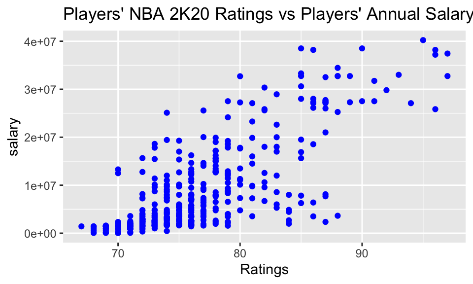

```r
dfnew = data %>%
  mutate(across(starts_with("salary"), ~gsub("\\$", "", .) %>% as.numeric))

ggplot(dfnew, aes(x=rating,y=salary))+
  geom_point(colour='blue')+
  labs(title="Players' NBA 2K20 Ratings vs Players' Annual Salary",
       x= "Ratings")
```

Interpretasi: Dari visualisasi ini bisa dilihat bahwa hubungan antar kedua variabel berbanding lurus dan memiliki hubungan yang lumayan tinggi. Apabila gajinya tinggi, ratingnya cenderung tinggi. Jadi bisa ditarik kesimpulan bahwa gaji kebanyakan gaji atlit cenderung seimbang dengan performanya, meskipun terlihat juga beberapa atlit yang ratingnya tinggi namun gajinya rendah, ini bisa saja terjadi karena atlit tersebut mengalami perkembangan performa pada tahun tersebut, sehingga gajinya masih rendah tetapi ratingnya tinggi. Begitu pun sebaliknya, ada yang gajinya dilihat tinggi dibandingkan performanya, ini bisa terjadi apabila performa atlit menurun pada tahun tersebut

### 3. Visualisasi Histogram Banyak Pemain Rated 80+ dalam sebuah team

Visualisasi ini untuk melihat berapa banyak pemain yang ratingnya di atas 80 dalam sebuah tim

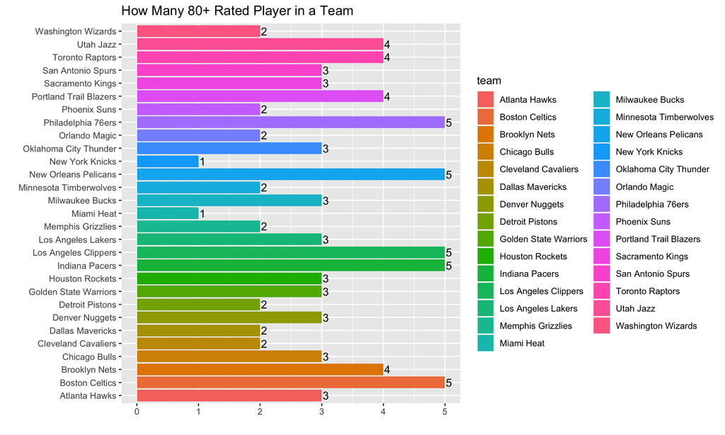

```r
pd = filter(dfnew, rating>=80)

pd1 = pd %>%
  count(team) %>%
  head(29)

ggplot(pd1) +
  geom_col(mapping=aes(x=team,y=n,fill=team))+
  geom_text(aes(x = team,y=n, label =n), hjust = -0.15)+
  labs(x='',y='',title="How Many 80+ Rated Player in a Team")+
  coord_flip()
```

Interpretasi: Di visualisasi ini saya asumsikan bahwa pemain yang performanya bagus adalah pemain dengan rating 80 dan 80 keatas. Dari visualisasi ini dilihat bahwa persebaran pemain bagus di team-team NBA season 20 dan kekuatan team ini kurang merata. Ada beberapa team yang hanya memiliki 1-2 pemain dengan rating 80 keatas. Bahkan untuk team Charlotte Hornets tidak ada di list karena tidak ada pemain dengan rating 80 keatas. Padahal, untuk persaingan yang lebih ketat dan lebih seru diharapkan kekuatan tiap team merata.

### 4. Visualisasi Scatter Plot Rating vs Age

Visualisasi ini menggunakan scatter plot untuk melihat bagaimana hubungan umur atlit dengan performanya

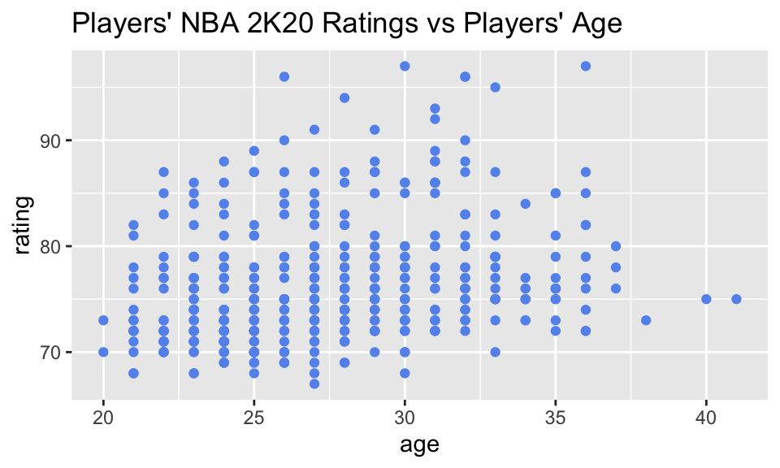

```r
dfnew$b_day = mdy(dfnew$b_day)
dfnew$age <- floor(age_calc(dfnew$b_day, units = "years"))

ggplot(dfnew, aes(x=age,y=rating))+
  geom_point(color='cornflowerblue')+
  labs(title="Players' NBA 2K20 Ratings vs Players' Age",
       x= "age")
```

Interpretasi: Dari visualisasi ini bisa kita lihat bahwa hubungan antara variabel umur dan rating tidak terlalu tinggi (cenderung rendah). Jadi dapat disimpulkan bahwa umur tidak terlalu berpengaruh pada performa pemain. Bisa dilihat juga bahwa pemain dengan rating 90 dan keatas semua berumur di atas 25, hal ini merupakan hal yang wajar karena berdasarkan survey dari sportcasting, dikatakan bahwa usia prima atlit adalah umur 27.

### 5. Visualisasi Histogram Banyak Pemain per Rating Score

Visualisasi ini untuk melihat berapa banyak atlit yang mendapat nilai rating tersebut

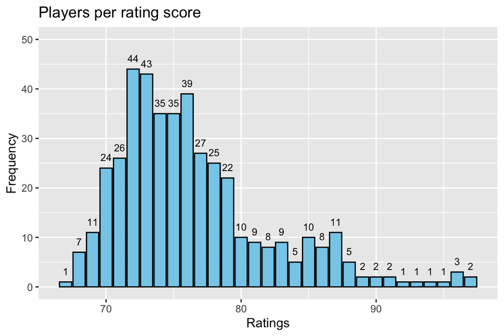

```r
pd4 = dfnew %>%
  count(rating) %>%
  arrange(desc(rating))

ggplot(pd4, aes(x=rating,y=n))+
  geom_col(color='black',fill='skyblue')+
  geom_text(aes(x = rating,y=n, label =n), vjust =-1, size=3)+
  scale_y_continuous(limits=c(0,50))+
  labs(y="Frequency",x="Ratings",
       title="Players per rating score")
```

### 6. Visualisasi Boxplot Distribusi Rating Berdasarkan Draftpick Round

Visualisasi ini untuk melihat bagaimana performa pemain menurut draft round nya

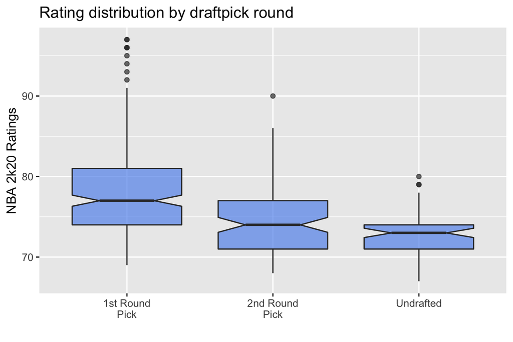

```r
ggplot(dfnew, aes(x=factor(draft_round, labels=c("1st Round\nPick",
                                                 "2nd Round\nPick",
                                                 "Undrafted")),
                  y=rating))+
  geom_boxplot(notch=TRUE,fill='cornflowerblue',alpha=0.7)+
  labs(title="Rating distribution by draftpick round",
       x="",y="NBA 2k20 Ratings")
```

Interpretasi: Dari visualisasi ini dapat dilihat bahwa pemain yang di draft di 1st round pick memiliki persebaran rating yang lebih tinggi, diikuti 2nd round pick dan undrafted. Hal ini sesuai dengan logika wajarnya. Dari visualisasi ini kita dapat simpulkan bahwa draft scouting di NBA sudah cukup baik.

### 7. Visualisasi Histogram 10 Negara dengan Pemain NBA terbanyak selain USA

Visualisasi ini untuk melihat jumlah pemain tiap negara selain USA yang bermain di NBA

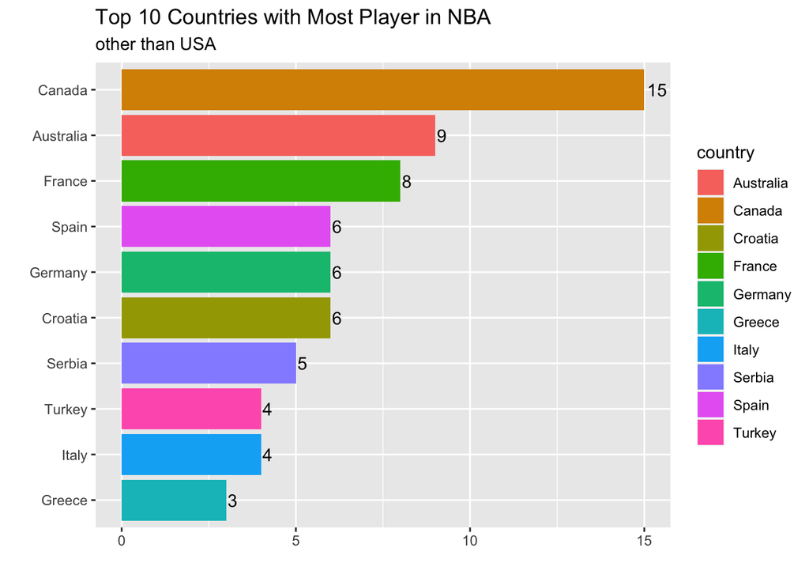

```r
pd6 = dfnew %>%
  count(country) %>%
  arrange(desc(n)) %>%
  head(11)
slice = pd6[2:11, ]

ggplot(slice) +
  geom_col(mapping=aes(x=reorder(country,n),y=n,fill=country))+
  geom_text(aes(x = country,y=n, label =n), hjust = -0.15)+
  labs(x='',y='',
       title="Top 10 Countries with Most Player in NBA",
       subtitle="other than USA")+
  coord_flip()
```